# Exploratory Data Analysis and Predictive Modeling for Default Risk Factors

## Introduction

As a prominent online retail lender, our company is currently facing an alarming increase in client default rates over the past year. This analysis aims to identify the most significant factors contributing to the likelihood of default, represented by the target variable `DlqIn2Years`. Understanding these factors is crucial for creating a strategic response to mitigate default risk and optimize customer management practices.

In this report, we will explore the dataset through a combination of statistical methods and machine learning models, prioritizing **transparency** to provide shareholders with clear, actionable insights. Our goal is not only to detect patterns but also to make the models and their findings interpretable and understandable by all stakeholders, ensuring that any decisions based on these findings are explainable and justifiable.

## Data Overview

The dataset includes 150,000 customer records with the following features:

- **DlqIn2Years**: Person experienced 90 days past due delinquency or worse.
- **AgeInYears**: Age of borrower in years.
- **MonthlyIncm**: Monthly income.
- **DebtRtio**: Monthly debt payments, alimony, living costs divided by monthly gross income.
- **NoOfDependents**: Number of dependents in family excluding themselves (spouse, children etc.).
- **NumberOfOpenCreditLinesAndLoans**: Number of open loans (installments like car loan or mortgage) and lines of credit (e.g., credit cards).
- **NoOfTime35-65DaysPastDueNotWorse**: Number of times borrower has been 35-65 days past due but no worse in the last 2 years.
- **NoOfTime60-89DaysPastDueNotWorse**: Number of times borrower has been 60-89 days past due but no worse in the last 2 years.
- **NoOfTimes90DaysLate**: Number of times borrower has been 90 days or more past due.
- **NoRealEstateLoansOrLines**: Number of mortgage and real estate loans including home equity lines of credit.
- **UtilizationOfUnsecLines**: Total balance on credit cards and personal lines of credit (excluding real estate and installment debt like car loans) divided by the sum of credit limits.

The target variable `DlqIn2Years` indicates whether the customer defaulted on a loan in the next two years (1 = Yes, 0 = No).

## Methodology

To uncover the factors contributing to the likelihood of default (`DlqIn2Years`), we performed an exploratory analysis followed by machine learning modeling.

The methodology for this analysis is as follows:

```python
# Data manipulation and numerical operations
import pandas as pd
import numpy as np

# Visualization libraries
import matplotlib.pyplot as plt
import seaborn as sns

# Machine learning libraries
from sklearn.model_selection import train_test_split, GridSearchCV
from sklearn.preprocessing import StandardScaler
from sklearn.utils import resample
from sklearn.linear_model import LogisticRegression, Lasso, Ridge
from sklearn.metrics import classification_report, confusion_matrix, roc_auc_score, roc_curve, accuracy_score
from sklearn.ensemble import RandomForestClassifier

# Statistical tests and models
from scipy.stats import ttest_ind, chi2_contingency
import statsmodels.api as sm
from statsmodels.stats.outliers_influence import variance_inflation_factor

import warnings

# Suppress FutureWarnings
warnings.filterwarnings('ignore', category=FutureWarning)
```

## 1. Data Loading and Initial Inspection

We begin by loading the dataset and performing an initial inspection to ensure it is clean and ready for analysis.

```python
# Load the dataset
data = pd.read_csv('cs-data.csv')

# Display the first few rows
data.head()
```

|  | ClientId | DlqIn2Years | UtilizationOfUnsecLines | AgeInYears | NoOfTime35-65DaysPastDueNotWorse | DebtRtio | MonthlyIncm | NoOfOpenCreditLinesAndLoans | NoOfTimes90DaysLate | NoRealEstateLoansOrLines | NoOfTime60-89DaysPastDueNotWorse | NoOfDependents |
| --- | --- | --- | --- | --- | --- | --- | --- | --- | --- | --- | --- | --- |
| 0 | 1 | 1 | 0.766127 | 45 | 2 | 0.802982 | 9120.0 | 13 | 0 | 6 | 0 | 2.0 |
| 1 | 2 | 0 | 0.957151 | 40 | 0 | 0.121876 | 2600.0 | 4 | 0 | 0 | 0 | 1.0 |
| 2 | 3 | 0 | 0.658180 | 38 | 1 | 0.085113 | 3042.0 | 2 | 1 | 0 | 0 | 0.0 |
| 3 | 4 | 0 | 0.233810 | 30 | 0 | 0.036050 | 3300.0 | 5 | 0 | 0 | 0 | 0.0 |
| 4 | 5 | 0 | 0.907239 | 49 | 1 | 0.024926 | 63588.0 | 7 | 0 | 1 | 0 | 0.0 |

```python
# Check data types and missing values
data.info()
```

```
<class 'pandas.core.frame.DataFrame'>
RangeIndex: 150000 entries, 0 to 149999
Data columns (total 12 columns):
 #   Column                            Non-Null Count   Dtype
---  ------                            --------------   -----
 0   ClientId                          150000 non-null  int64
 1   DlqIn2Years                       150000 non-null  int64
 2   UtilizationOfUnsecLines           150000 non-null  float64
 3   AgeInYears                        150000 non-null  int64
 4   NoOfTime35-65DaysPastDueNotWorse  150000 non-null  int64
 5   DebtRtio                          150000 non-null  float64
 6   MonthlyIncm                       120269 non-null  float64
 7   NoOfOpenCreditLinesAndLoans       150000 non-null  int64
 8   NoOfTimes90DaysLate               150000 non-null  int64
 9   NoRealEstateLoansOrLines          150000 non-null  int64
 10  NoOfTime60-89DaysPastDueNotWorse  150000 non-null  int64
 11  NoOfDependents                    146076 non-null  float64
dtypes: float64(4), int64(8)
memory usage: 13.7 MB
```

```python
# Summary statistics
data.describe()
```

|  | ClientId | DlqIn2Years | UtilizationOfUnsecLines | AgeInYears | NoOfTime35-65DaysPastDueNotWorse | DebtRtio | MonthlyIncm | NoOfOpenCreditLinesAndLoans | NoOfTimes90DaysLate | NoRealEstateLoansOrLines | NoOfTime60-89DaysPastDueNotWorse | NoOfDependents |
| --- | --- | --- | --- | --- | --- | --- | --- | --- | --- | --- | --- | --- |
| count | 150000.000000 | 150000.000000 | 150000.000000 | 150000.000000 | 150000.000000 | 150000.000000 | 1.202690e+05 | 150000.000000 | 150000.000000 | 150000.000000 | 150000.000000 | 146076.000000 |
| mean | 75000.500000 | 0.066840 | 6.048438 | 52.295207 | 0.421033 | 353.005076 | 6.670221e+03 | 8.452760 | 0.265973 | 1.018240 | 0.240387 | 0.757222 |
| std | 43301.414527 | 0.249746 | 249.755371 | 14.771866 | 4.192781 | 2037.818523 | 1.438467e+04 | 5.145951 | 4.169304 | 1.129771 | 4.155179 | 1.115086 |
| min | 1.000000 | 0.000000 | 0.000000 | 0.000000 | 0.000000 | 0.000000 | 0.000000e+00 | 0.000000 | 0.000000 | 0.000000 | 0.000000 | 0.000000 |
| 25% | 37500.750000 | 0.000000 | 0.029867 | 41.000000 | 0.000000 | 0.175074 | 3.400000e+03 | 5.000000 | 0.000000 | 0.000000 | 0.000000 | 0.000000 |
| 50% | 75000.500000 | 0.000000 | 0.154181 | 52.000000 | 0.000000 | 0.366508 | 5.400000e+03 | 8.000000 | 0.000000 | 1.000000 | 0.000000 | 0.000000 |
| 75% | 112500.250000 | 0.000000 | 0.559046 | 63.000000 | 0.000000 | 0.868254 | 8.249000e+03 | 11.000000 | 0.000000 | 2.000000 | 0.000000 | 1.000000 |
| max | 150000.000000 | 1.000000 | 50708.000000 | 109.000000 | 98.000000 | 329664.000000 | 3.008750e+06 | 58.000000 | 98.000000 | 54.000000 | 98.000000 | 20.000000 |

### Handling Missing Values

We address missing values by filling them with appropriate measures.

```python
# Check for missing values
data.isnull().sum()
```

```
ClientId                                0
DlqIn2Years                             0
UtilizationOfUnsecLines                 0
AgeInYears                              0
NoOfTime35-65DaysPastDueNotWorse        0
DebtRtio                                0
MonthlyIncm                         29731
NoOfOpenCreditLinesAndLoans             0
NoOfTimes90DaysLate                     0
NoRealEstateLoansOrLines                0
NoOfTime60-89DaysPastDueNotWorse        0
NoOfDependents                       3924
dtype: int64
```

```python
# Fill missing values with median for numerical columns
data['MonthlyIncm'].fillna(data['MonthlyIncm'].median(), inplace=True)
data['NoOfDependents'].fillna(data['NoOfDependents'].median(), inplace=True)

# Verify no more missing values
data.isnull().sum()
```

```
ClientId                            0
DlqIn2Years                         0
UtilizationOfUnsecLines             0
AgeInYears                          0
NoOfTime35-65DaysPastDueNotWorse    0
DebtRtio                            0
MonthlyIncm                         0
NoOfOpenCreditLinesAndLoans         0
NoOfTimes90DaysLate                 0
NoRealEstateLoansOrLines            0
NoOfTime60-89DaysPastDueNotWorse    0
NoOfDependents                      0
dtype: int64
```

```python
# Separate majority and minority classes
majority = data[data.DlqIn2Years == 0]
minority = data[data.DlqIn2Years == 1]

# Upsample minority class
minority_upsampled = resample(minority,
                              replace=True,  # Sample with replacement
                              n_samples=len(majority),  # Match number of majority samples
                              random_state=42)

# Combine majority class with upsampled minority class
balanced_data = pd.concat([majority, minority_upsampled])
#data = balanced_data
```

## 2. Exploratory Data Analysis (EDA)

We perform EDA to understand the data distribution and relationships between features and the target variable.

### 2.1 Analyzing the Target Variable

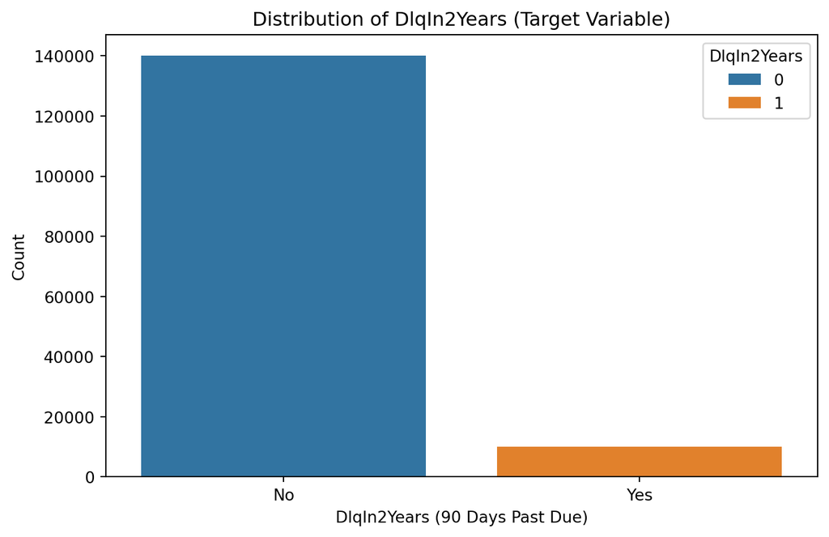

```python
# Plot the distribution of the target variable
plt.figure(figsize=(8, 5))
sns.countplot(x='DlqIn2Years', data=data, hue='DlqIn2Years')
plt.title('Distribution of DlqIn2Years (Target Variable)')
plt.xticks([0, 1], ['No', 'Yes'])
plt.xlabel('DlqIn2Years (90 Days Past Due)')
plt.ylabel('Count')
##plt.show()
```

**Observation**: The dataset is imbalanced with significantly more non-delinquent clients.

### 2.2 Univariate Analysis

Age Distribution

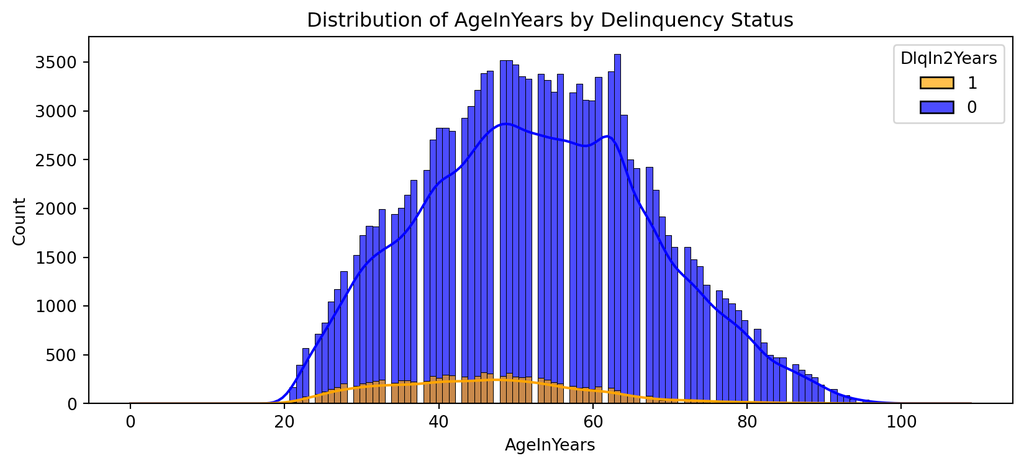

```python
# Plotting Age Distribution
plt.figure(figsize=(10, 4))
sns.histplot(data=data, x='AgeInYears', hue='DlqIn2Years', multiple='layer', alpha=0.7, kde=True, hue_order=[1, 0], palette={0: 'blue', 1: 'orange'})
plt.title('Distribution of AgeInYears by Delinquency Status')
##plt.show()
```

**Observation**: Most customers are between 20 and 60 years old.

Utilization of Unsecured Lines

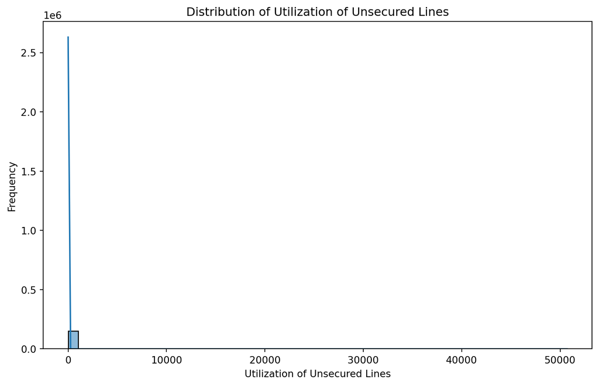

```python
# Plot utilization distribution
plt.figure(figsize=(10, 6))
sns.histplot(data['UtilizationOfUnsecLines'], bins=50, kde=True)
plt.title('Distribution of Utilization of Unsecured Lines')
plt.xlabel('Utilization of Unsecured Lines')
plt.ylabel('Frequency')
#plt.show()
```

**Observation**: The distribution is heavily skewed with outliers at high utilization levels.

### 2.3 Bivariate Analysis

```python
def bivariate_plot(column, xlabel, ylabel):
    plt.figure(figsize=(10, 6))
    sns.boxplot(x='DlqIn2Years', y=column, data=data, hue='DlqIn2Years', hue_order=[1, 0], palette={0: 'blue', 1: 'orange'})
    plt.title(f'{column} vs DlqIn2Years')
    if xlabel:
        plt.xlabel(xlabel)
    if ylabel:
        plt.ylabel(ylabel)
    #plt.show()
```

Age vs. Delinquency

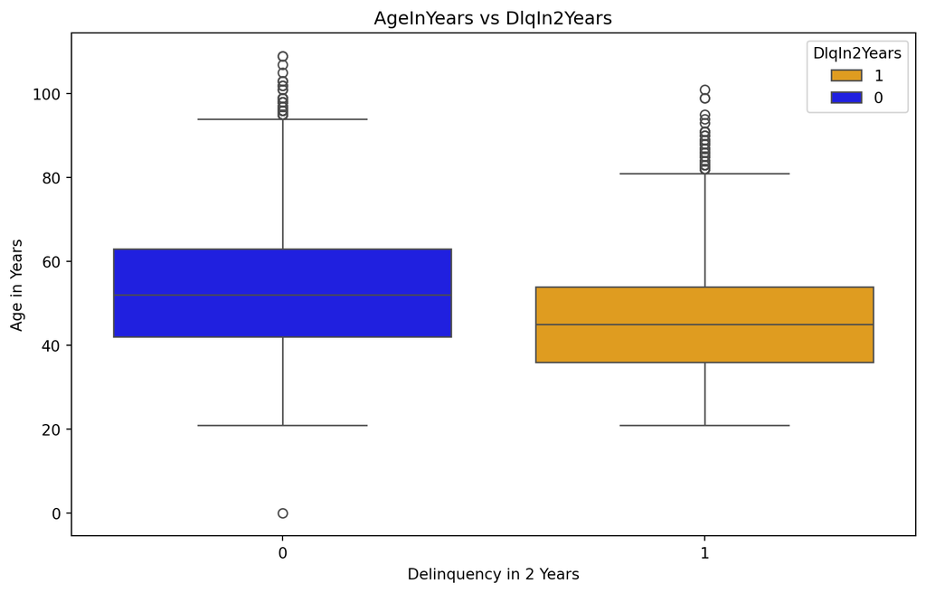

```python
bivariate_plot('AgeInYears', 'Delinquency in 2 Years', 'Age in Years')
```

**Observation**: Delinquent clients tend to be younger on average.

Debt Ratio vs. Delinquency

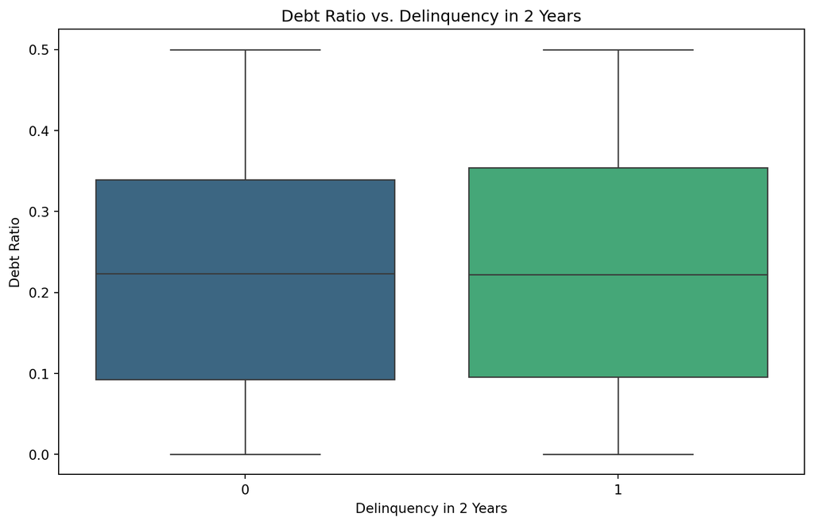

```python
# Boxplot of Debt Ratio vs. Delinquency
plt.figure(figsize=(10, 6))
sns.boxplot(x='DlqIn2Years', y='DebtRtio', data=data[data['DebtRtio'] < 0.5], palette='viridis')
plt.title('Debt Ratio vs. Delinquency in 2 Years')
plt.xlabel('Delinquency in 2 Years')
plt.ylabel('Debt Ratio')
#plt.show()
```

- We see that the dataset is imbalanced with more non-delinquent clients.
- Basic summary statistics show variance across features like age, income, and utilization of credit lines.

### 2.4 Correlation Matrix

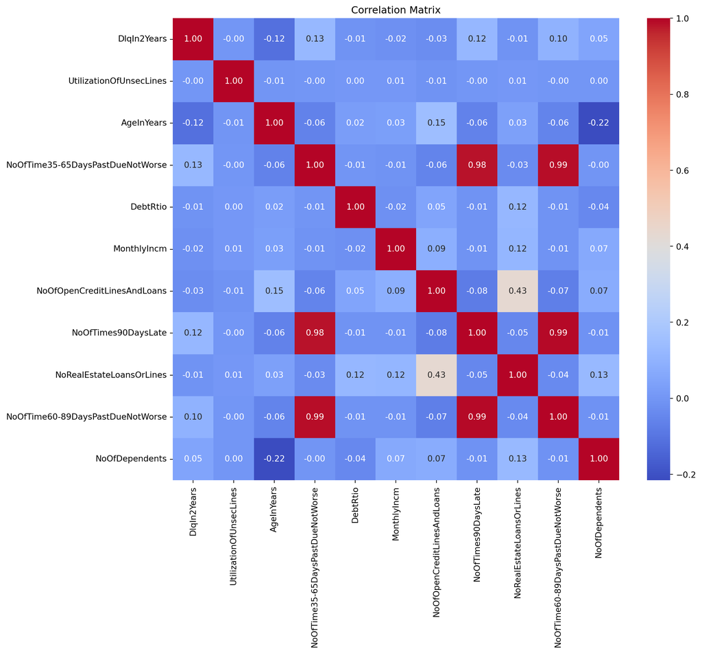

```python
# Correlation matrix
corr_matrix = data.drop('ClientId', axis=1).corr()

# Plot correlation heatmap
plt.figure(figsize=(12, 10))
sns.heatmap(corr_matrix, annot=True, fmt=".2f", cmap='coolwarm')
plt.title('Correlation Matrix')
#plt.show()
```

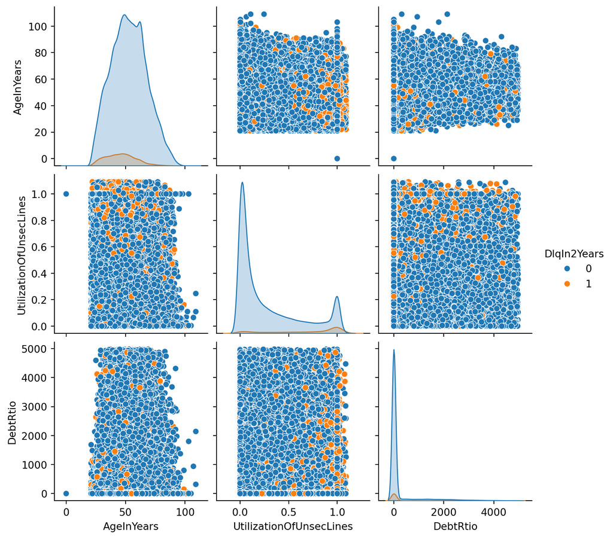

```python
# Remove outliers based on percentiles
filtered_data = data[
    (data['UtilizationOfUnsecLines'] < data['UtilizationOfUnsecLines'].quantile(0.99)) &
    (data['DebtRtio'] < data['DebtRtio'].quantile(0.99))
]

# Plot the pairplot after removing outliers
sns.pairplot(filtered_data, vars=["AgeInYears", "UtilizationOfUnsecLines", "DebtRtio"], hue="DlqIn2Years")
#plt.show()
```

## 3. Statistical Analysis

### 3.1 T-Tests for Continuous Variables

```python
# Function to perform T-test
def perform_ttest(feature):
    group1 = data[data['DlqIn2Years'] == 1][feature]
    group0 = data[data['DlqIn2Years'] == 0][feature]
    t_stat, p_value = ttest_ind(group1, group0)
    print(f"T-test for {feature}: t-statistic = {t_stat:.2f}, p-value = {p_value:.4f}")

# Continuous features
continuous_features = ['AgeInYears', 'MonthlyIncm', 'DebtRtio', 'UtilizationOfUnsecLines']

# Perform T-tests
for feature in continuous_features:
    perform_ttest(feature)
```

```
T-test for AgeInYears: t-statistic = -44.99, p-value = 0.0000
T-test for MonthlyIncm: t-statistic = -6.64, p-value = 0.0000
T-test for DebtRtio: t-statistic = -2.94, p-value = 0.0032
T-test for UtilizationOfUnsecLines: t-statistic = -0.70, p-value = 0.4854
```

### 3.2 Chi-Squared Tests for Categorical Variables

```python
# Function to perform Chi-squared test
def perform_chi2_test(feature):
    contingency_table = pd.crosstab(data[feature], data['DlqIn2Years'])
    chi2, p_value, dof, expected = chi2_contingency(contingency_table)
    print(f"Chi-squared test for {feature}: chi2 = {chi2:.2f}, p-value = {p_value:.4f}")

#print(data.columns)
# Categorical features
categorical_features = ['NoOfDependents', 'NoOfOpenCreditLinesAndLoans', 'NoRealEstateLoansOrLines']

# Perform Chi-squared tests
for feature in categorical_features:
    perform_chi2_test(feature)
```

```
Chi-squared test for NoOfDependents: chi2 = 354.48, p-value = 0.0000
Chi-squared test for NoOfOpenCreditLinesAndLoans: chi2 = 1692.74, p-value = 0.0000
Chi-squared test for NoRealEstateLoansOrLines: chi2 = 740.91, p-value = 0.0000
```

**Observation**: Significant associations with the target variable.

## 4. Feature Engineering

### 4.1 Handling Multicollinearity Using VIF

```python
# Exclude target and identifiers
variables = data.drop(columns=['DlqIn2Years', 'ClientId'])

# Compute VIF
vif_data = pd.DataFrame()
vif_data["Feature"] = variables.columns
vif_data["VIF"] = [variance_inflation_factor(variables.values, i) for i in range(len(variables.columns))]
print("Variance Inflation Factor (VIF) for Each Feature:")
print(vif_data)
```

```
Variance Inflation Factor (VIF) for Each Feature:
                            Feature        VIF
0           UtilizationOfUnsecLines   1.000777
1                        AgeInYears   3.638439
2  NoOfTime35-65DaysPastDueNotWorse  41.173243
3                          DebtRtio   1.049552
4                       MonthlyIncm   1.269632
5       NoOfOpenCreditLinesAndLoans   4.570548
6               NoOfTimes90DaysLate  73.196237
7          NoRealEstateLoansOrLines   2.304678
8  NoOfTime60-89DaysPastDueNotWorse  91.181441
9                    NoOfDependents   1.403443
```

**Observation**: High VIF values indicate multicollinearity among delinquency features.

### 4.2 Reducing Multicollinearity

```python
# Drop features with high VIF
data_reduced = data.drop(columns=['NoOfTime35-65DaysPastDueNotWorse', 'NoOfTime60-89DaysPastDueNotWorse'])
```

### 4.3 Creating New Features

```python
# Define features and target
X = data_reduced.drop(columns=['DlqIn2Years', 'ClientId'])
y = data_reduced['DlqIn2Years']

# Create interaction terms
X['DebtRtio_MonthlyIncm'] = X['DebtRtio'] * X['MonthlyIncm']
X['AgeInYears_NoOfDependents'] = X['AgeInYears'] * X['NoOfDependents']

# Apply non-linear transformations
X['Log_UtilizationOfUnsecLines'] = np.log(X['UtilizationOfUnsecLines'] + 1e-6)
X['Log_MonthlyIncm'] = np.log(X['MonthlyIncm'] + 1e-6)
```

## 5. Data Preparation for Modeling

### 5.1 Feature Scaling and Splitting

```python
# Feature names
features = X.columns

# Standardize features
scaler = StandardScaler()
X_scaled = scaler.fit_transform(X)

# Split data into training and test sets
X_train, X_test, y_train, y_test = train_test_split(
    X_scaled, y, test_size=0.3, random_state=42, stratify=y
)
```

## 6. Machine Learning Models

### 6.1 Logistic Regression with Regularization

Lasso Regression (L1 Penalty)

```python
# Instantiate logistic regression with L1 penalty
lasso_model = LogisticRegression(penalty='l1', solver='saga', max_iter=5000, random_state=42)

# Parameter grid for C
param_grid = {'C': np.logspace(-4, 4, 20)}

# Grid search with cross-validation
lasso_cv = GridSearchCV(lasso_model, param_grid, cv=5, scoring='roc_auc', n_jobs=-1)
lasso_cv.fit(X_train, y_train)
print("Best Lasso C:", lasso_cv.best_params_)
```

```
Best Lasso C: {'C': 1.623776739188721}
```

Ridge Regression (L2 Penalty)

```python
# Instantiate logistic regression with L2 penalty
ridge_model = LogisticRegression(penalty='l2', solver='saga', max_iter=5000, random_state=42)

# Grid search with cross-validation
ridge_cv = GridSearchCV(ridge_model, param_grid, cv=5, scoring='roc_auc', n_jobs=-1)
ridge_cv.fit(X_train, y_train)
print("Best Ridge C:", ridge_cv.best_params_)
```

```
Best Ridge C: {'C': 1438.44988828766}
```

### 6.2 Random Forest Classifier

```python
# Random Forest Model
rf_model = RandomForestClassifier(random_state=42)
rf_model.fit(X_train, y_train)

# Predictions
y_pred_rf = rf_model.predict(X_test)
```

## 7. Model Evaluation

### 7.1 Evaluate Regularized Models

```python
# Predict probabilities
y_pred_prob_lasso = lasso_cv.best_estimator_.predict_proba(X_test)[:, 1]
y_pred_prob_ridge = ridge_cv.best_estimator_.predict_proba(X_test)[:, 1]

# Calculate AUC
auc_lasso = roc_auc_score(y_test, y_pred_prob_lasso)
auc_ridge = roc_auc_score(y_test, y_pred_prob_ridge)
print("Lasso AUC:", auc_lasso)
print("Ridge AUC:", auc_ridge)
```

```
Lasso AUC: 0.774984483651648
Ridge AUC: 0.7749496096710923
```

### 7.2 ROC Curves

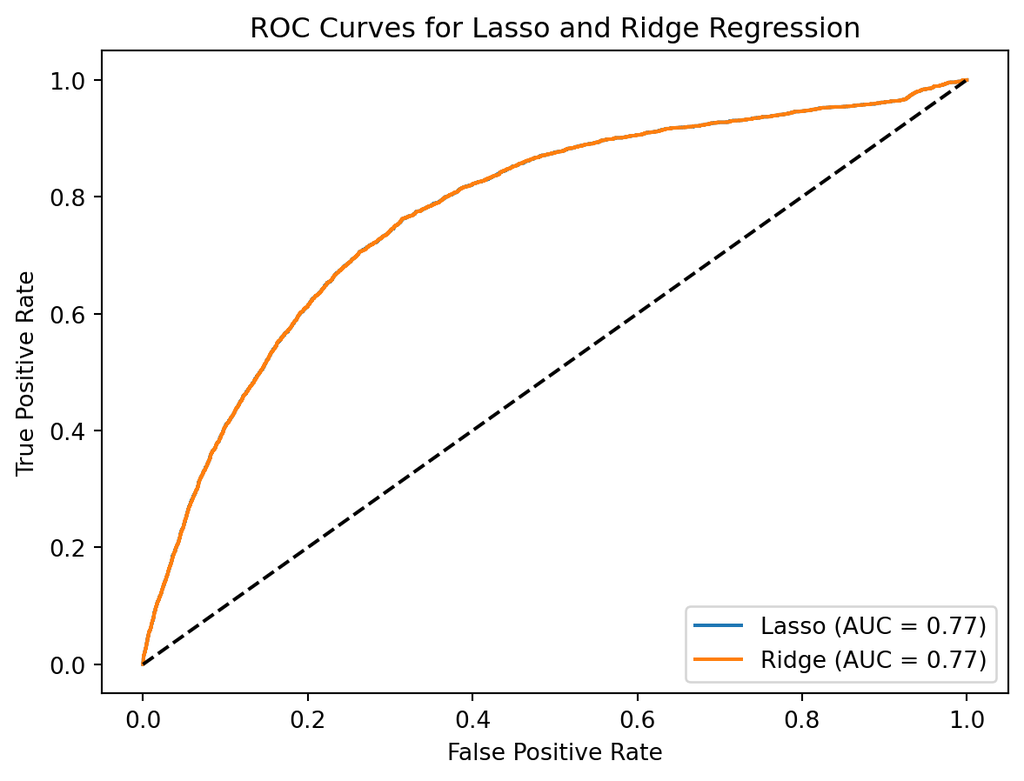

```python
# ROC Curves
fpr_lasso, tpr_lasso, _ = roc_curve(y_test, y_pred_prob_lasso)
fpr_ridge, tpr_ridge, _ = roc_curve(y_test, y_pred_prob_ridge)

plt.figure()
plt.plot(fpr_lasso, tpr_lasso, label='Lasso (AUC = %0.2f)' % auc_lasso)
plt.plot(fpr_ridge, tpr_ridge, label='Ridge (AUC = %0.2f)' % auc_ridge)
plt.plot([0, 1], [0, 1], 'k--')  # Diagonal line
plt.xlabel('False Positive Rate')
plt.ylabel('True Positive Rate')
plt.title('ROC Curves for Lasso and Ridge Regression')
plt.legend(loc='lower right')
#plt.show()
```

### 7.3 Random Forest Evaluation

```python
# Evaluate Random Forest
print(f"Random Forest Accuracy: {accuracy_score(y_test, y_pred_rf):.4f}")
print(f"Random Forest Classification Report:\n{classification_report(y_test, y_pred_rf)}")
```

```
Random Forest Accuracy: 0.9349
Random Forest Classification Report:
              precision    recall  f1-score   support

           0       0.94      0.99      0.97     41992
           1       0.55      0.15      0.24      3008

    accuracy                           0.93     45000
   macro avg       0.75      0.57      0.60     45000
weighted avg       0.92      0.93      0.92     45000
```

## 8. Feature Importance Analysis

### 8.1 Coefficients from Regularized Models

```python
# Lasso Coefficients
lasso_coef = pd.Series(lasso_cv.best_estimator_.coef_[0], index=features)
print("Lasso Coefficients:")
print(lasso_coef.sort_values(key=abs, ascending=False))

# Ridge Coefficients
ridge_coef = pd.Series(ridge_cv.best_estimator_.coef_[0], index=features)
print("Ridge Coefficients:")
print(ridge_coef.sort_values(key=abs, ascending=False))
```

```
Lasso Coefficients:
Log_UtilizationOfUnsecLines    1.324860
MonthlyIncm                   -0.570023
UtilizationOfUnsecLines       -0.286535
AgeInYears                    -0.266086
NoOfDependents                 0.228188
AgeInYears_NoOfDependents     -0.149680
NoOfTimes90DaysLate            0.120507
Log_MonthlyIncm                0.092043
NoRealEstateLoansOrLines       0.081221
DebtRtio_MonthlyIncm          -0.078117
NoOfOpenCreditLinesAndLoans    0.003609
DebtRtio                       0.000505
dtype: float64
Ridge Coefficients:
Log_UtilizationOfUnsecLines    1.326083
MonthlyIncm                   -0.575700
UtilizationOfUnsecLines       -0.287837
AgeInYears                    -0.264561
NoOfDependents                 0.239539
AgeInYears_NoOfDependents     -0.161455
NoOfTimes90DaysLate            0.120595
Log_MonthlyIncm                0.093871
DebtRtio_MonthlyIncm          -0.089937
NoRealEstateLoansOrLines       0.081681
DebtRtio                       0.011846
NoOfOpenCreditLinesAndLoans    0.003948
dtype: float64
```

### 8.2 Feature Importances from Random Forest

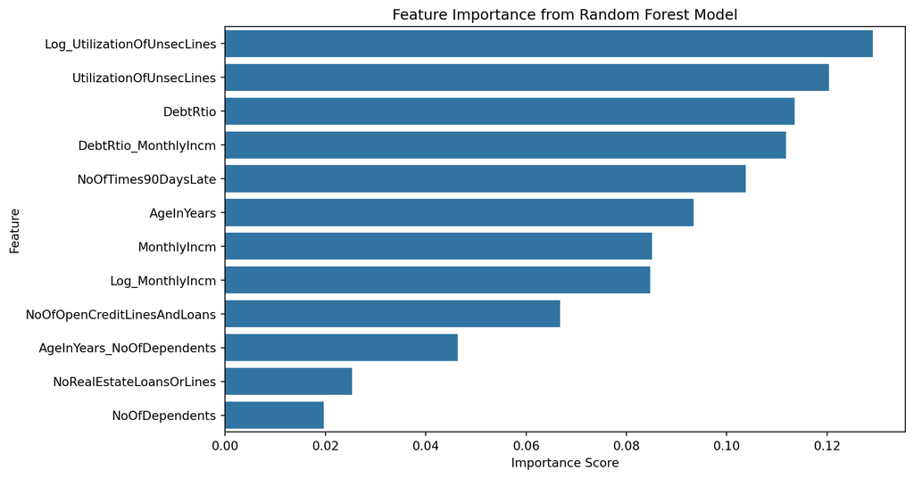

```python
# Random Forest Feature Importances
importances = rf_model.feature_importances_
feature_importance_df = pd.DataFrame({'Feature': features, 'Importance': importances})
feature_importance_df = feature_importance_df.sort_values(by='Importance', ascending=False)

# Plotting Feature Importances
plt.figure(figsize=(10, 6))
sns.barplot(x='Importance', y='Feature', data=feature_importance_df)
plt.title('Feature Importance from Random Forest Model')
plt.xlabel('Importance Score')
plt.ylabel('Feature')
#plt.show()
```

## 9. Model Interpretation with StatsModels

```python
# Create DataFrame with standardized features
X_train_df = pd.DataFrame(X_train, columns=features)
X_train_df.reset_index(drop=True, inplace=True)  # Reset index
X_train_df = sm.add_constant(X_train_df)

## Check for NaN values
#print("Number of NaNs in X_train_df:")
#print(X_train_df.isna().sum())
#
## Check for infinite values
#print("\nNumber of infinite values in X_train_df:")
#print(np.isinf(X_train_df).sum())

# Reset index of y_train
y_train = y_train.reset_index(drop=True)

# Fit logistic regression model
logit_model = sm.Logit(y_train, X_train_df)
result = logit_model.fit()
print(result.summary())
```

```
Optimization terminated successfully.
         Current function value: 0.222804
         Iterations 9
                           Logit Regression Results
==============================================================================
Dep. Variable:            DlqIn2Years   No. Observations:               105000
Model:                          Logit   Df Residuals:                   104987
Method:                           MLE   Df Model:                           12
Date:                Thu, 17 Oct 2024   Pseudo R-squ.:                 0.09201
Time:                        10:58:40   Log-Likelihood:                -23394.
converged:                       True   LL-Null:                       -25765.
Covariance Type:            nonrobust   LLR p-value:                     0.000
===============================================================================================
                                  coef    std err          z      P>|z|      [0.025      0.975]
-----------------------------------------------------------------------------------------------
const                          -3.1608      0.021   -149.755      0.000      -3.202      -3.119
UtilizationOfUnsecLines        -0.2879      0.037     -7.733      0.000      -0.361      -0.215
AgeInYears                     -0.2632      0.016    -15.988      0.000      -0.295      -0.231
DebtRtio                        0.1284      0.118      1.092      0.275      -0.102       0.359
MonthlyIncm                    -0.5843      0.055    -10.631      0.000      -0.692      -0.477
NoOfOpenCreditLinesAndLoans     0.0038      0.015      0.253      0.800      -0.025       0.033
NoOfTimes90DaysLate             0.1208      0.007     16.503      0.000       0.106       0.135
NoRealEstateLoansOrLines        0.0815      0.014      5.751      0.000       0.054       0.109
NoOfDependents                  0.2524      0.056      4.534      0.000       0.143       0.361
DebtRtio_MonthlyIncm           -0.2072      0.119     -1.744      0.081      -0.440       0.026
AgeInYears_NoOfDependents      -0.1753      0.058     -3.012      0.003      -0.289      -0.061
Log_UtilizationOfUnsecLines     1.3261      0.035     37.968      0.000       1.258       1.395
Log_MonthlyIncm                 0.1053      0.021      5.057      0.000       0.065       0.146
===============================================================================================
```